# Tarea 2

Martin Santamaria

25/10/2020

### Ejercicio 1

Estimamos el parámetro $b$ a partir del momento de orden 1 $M_1 = \overline{X}$ donde $\overline{X} = E(X) = \frac{a+b}{2}$

hallamos $\overline{X}$

```r
registro_lluvias = c(0,0,0.7,1,0.1,0,0.2,0.5,0,0.6)
media = mean(registro_lluvias)
```

y despejamos $\hat{b}$ de la fórmula de $E(X)$ teniendo en cuenta que $a = 0$

```r
(estimador_b = media*2)
```

```
## [1] 0.62
```

### Ejercicio 2

Los estimadores de los parámetros $\mu$ y $\sigma$ de una normal son:

$\hat{u} = \overline{x}$

$\hat{\sigma}^2 = s^2$ donde $s^2 = \frac{1}{n-1}\sum_{i=1}^n(x_i-\overline{x})^2$ es la varianza muestral.

Procedemos a calcular lo pedido utilizando `R`

$\hat{u}$

```r
crecimiento.pinos = c(0.9144,1.524,0.6096,0.4572,1.0668)
mean(crecimiento.pinos)
```

```
## [1] 0.9144
```

$\hat{\sigma}^2$

`R` ya nos proporciona la varianza muestral con la función `var`

```r
var(crecimiento.pinos)
```

```
## [1] 0.1741932
```

### Ejercicio 3

Tal como hicimos en el ejercicio 1, estimamos el parámetro $p$ a partir del momento de orden 1 $M_1 = \overline{X}$ donde $\overline{X} = E(X) = \frac{1}{p}$ y por tanto $\hat{p} = \frac{1}{\overline{X}}$

### Ejercicio 4

Mismo caso anterior. Estimamos el parámetro $\lambda$ a partir del momento de orden 1 $M_1 = \overline{X}$ donde $\overline{X} = E(X) = \frac{1}{\lambda}$ y por tanto $\hat{\lambda} = \frac{1}{\overline{X}}$

### Ejercicio 5

Misma idea que los anteriores. El momento de orden 1 de una uniforme es $M_1 = \overline{X}$ donde $\overline{X} = E(X) = \frac{a+b}{2}$ donde $a = b - \frac{1}{4}$. Despejamos $\hat{b}$

### Ejercicio 6

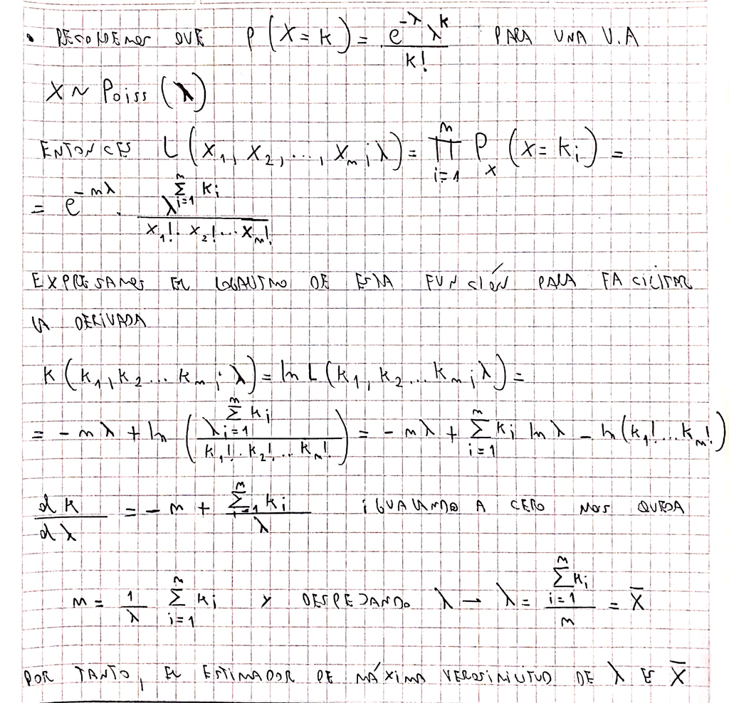